# Snap Data Analyst Assessment: Ann Henriksen

# 1 OBJECTIVE: Analyze a subset of customer applications.

## 1.1 What are the descriptive statistics for customers’ funded amounts?

```r
summary(customer$funded_amount)
```

```
##    Min. 1st Qu.  Median    Mean 3rd Qu.    Max.    NA's
##   250.0   777.5  1167.0  1255.1  1657.0  2992.0    2946
```

We see that the smallest lease amount is $ 250.00, and the largest is $2992.00. The data has a median $1167.00 and the mean of $1255.10.

Represented graphically:

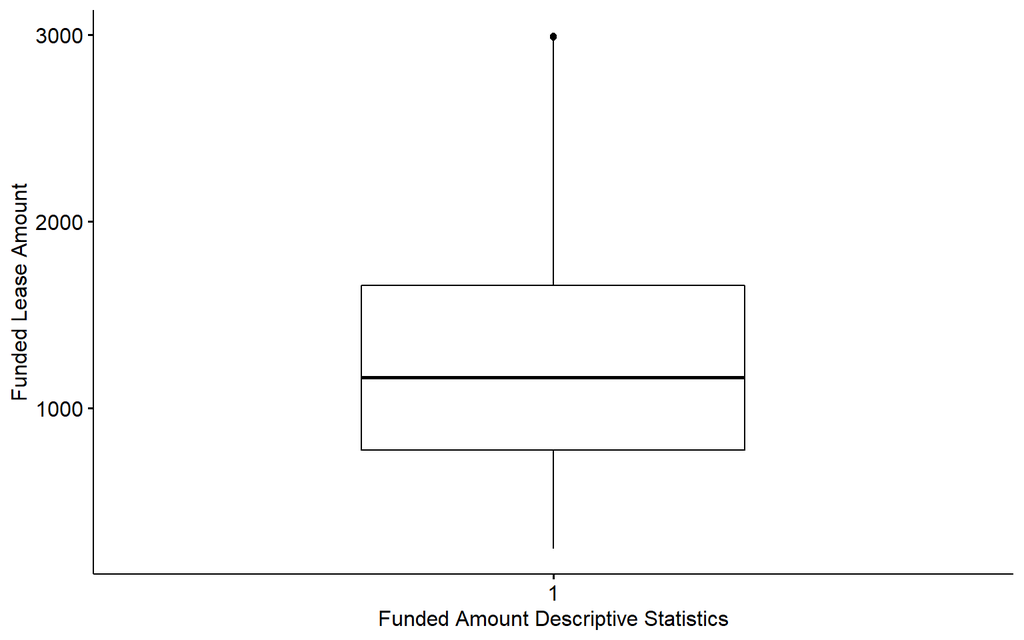

```r
ggboxplot(customer, y = "funded_amount", width = 0.5)+
  ylab("Funded Lease Amount")+
  xlab("Funded Amount Descriptive Statistics")
```

## 1.2 What percent of completed leases are completed within seven days of submitting their application?

```r
#New dataframe with only completed loans:
completed <- subset(customer, completed == 1)

#convert date format
completed$submit_time1 <- as.Date(completed$submit_time,
  format = "%m/%d/%y")

completed$completed_time1 <- as.Date(completed$completed_time,
  format = "%m/%d/%y")

#calculate how many days to completion
completed$Days_To_Complete <-difftime(completed$completed_time1,completed$submit_time1, units=c("days"))

#find and count how many out of 2283 observations
#narrowing the data to only leases completed within seven days and finding percentage

Week <- subset(completed, Days_To_Complete <= 7)

count(Week)/count(completed)
```

```
##          n
## 1 0.521682
```

52.17% of completed leases are completed within seven days of submitting their application.

We can also see this graphically:

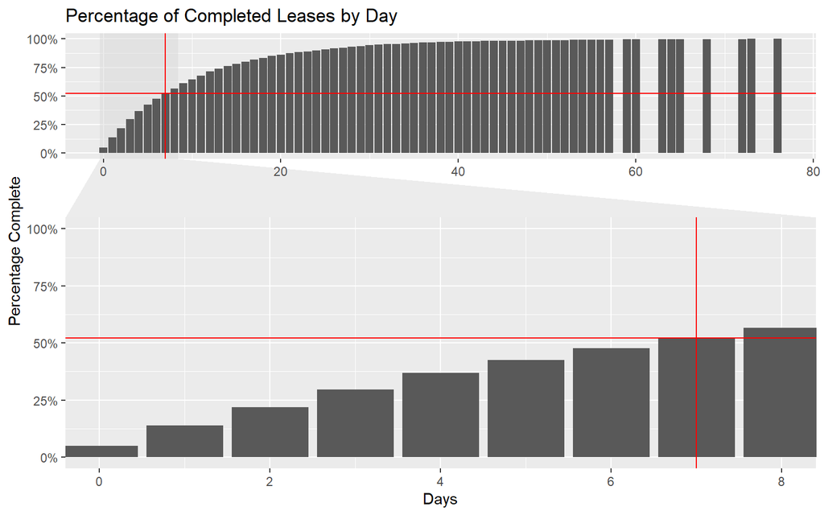

```r
ggplot(completed, aes(x = Days_To_Complete)) +


  geom_bar(aes(y = cumsum(..count..)/sum(..count..))) +
  scale_y_continuous(labels = percent)+
  ylab("Percentage Complete")+
  xlab("Days")+

  facet_zoom(xlim = c(0, 8))+
  labs(title = "Percentage of Completed Leases by Day")+

  geom_vline(xintercept = 7, colour = "red")+
  geom_hline(yintercept = .5217, colour = "red")
```

We first see the big picture with all of data; some closing on the day of application, and one even taking as long as 76 days.

We see an elbow where we can estimate that by 30 days the probability that the application is completed is near 90%.

We can zoom in a little bit to take a look at our data period in question, which is how many leases are completed within a week of submitting the application. We see that at that point in time, we have just over 50% of the lease applications completed, coming in at 52.17% on the seventh day.

## 1.3 What is the overall approval rate (percent of applications approved) and completion rate (percent of completions per approvals) for this subset?

```r
#Approval rate:
customer %>%
    count(approved = factor(approved)) %>%
    mutate(pct = prop.table(n))
```

```
##   approved    n       pct
## 1        0 1477 0.2824632
## 2        1 3752 0.7175368
```

71.75 % of applications are approved.

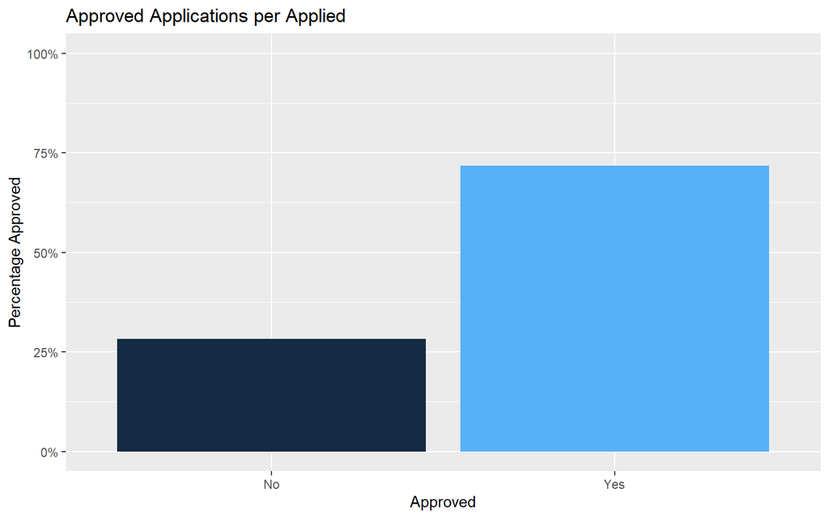

```r
ggplot(customer, aes(x = factor(approved), fill = approved)) +


  geom_bar(aes(y = (..count..)/sum(..count..))) +
  scale_y_continuous(labels = percent, limits=c(0,1))+
  ylab("Percentage Approved")+

  xlab("Approved")+
  scale_x_discrete(labels=c("-0.5" = " ", "0" = "No", "0.5" = " ", "1" = "Yes",
                              "1.5" = " "))+
  theme(legend.position="none")+
  labs(
    title = "Approved Applications per Applied")
```

Of those approved, we can find how many are completed:

```r
Approved <- subset(customer, approved == 1)

Approved %>%
    count(approved = factor(approved), completed = factor(completed)) %>%
    mutate(pct = prop.table(n))
```

```
##   approved completed    n       pct
## 1        1         0 1469 0.3915245
## 2        1         1 2283 0.6084755
```

There is a 61% completion rate of those who are approved.

This can also be seen graphically:

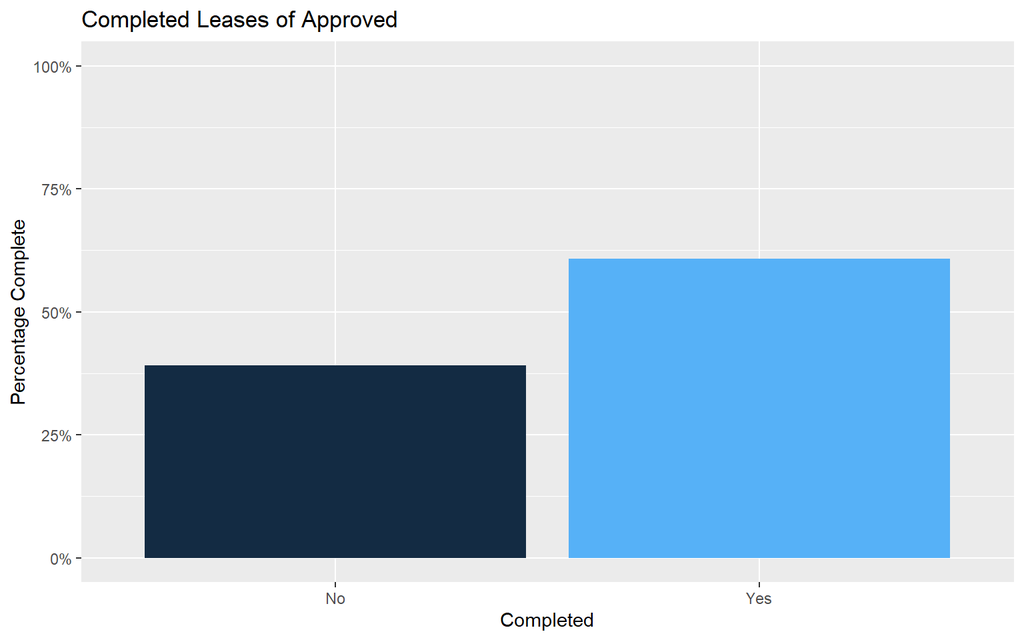

```r
ggplot(Approved, aes(x = factor(completed), fill = completed)) +


  geom_bar(aes(y = (..count..)/sum(..count..))) +
  scale_y_continuous(labels = percent, limits=c(0,1))+

  ylab("Percentage Complete")+
  xlab("Completed")+

  scale_x_discrete(breaks=c("-0.5","0", "0.5", "1","1.5"),
        labels=c("", "No", "", "Yes", ""))+
  theme(legend.position="none")+
    labs(
    title = "Completed Leases of Approved")
```

## 1.4 Is there a difference in approval rates among the various application sources?

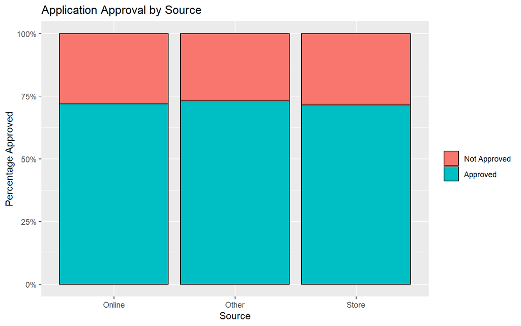

```r
customer1 <- customer%>%

  group_by(application_source, approved) %>%
  count() %>%
  ungroup() %>%
  mutate(prop = n/sum(n))

ggplot(customer1, aes(x = application_source, y = prop, fill = factor(approved))) +
  geom_col(colour = "black", position = "fill") +
  scale_y_continuous(labels = scales::percent) +

  scale_fill_discrete(name = "", labels = c("Not Approved", "Approved"))+
  xlab("Source")+
  ylab("Percentage Approved")+
  labs(title = "Application Approval by Source")
```

The Percent Stacked Bar Plot indicates that the rates of approval by Application Source are very similar. Applications received by the “Other” application source have a slightly higher rate of approval. We can look at this information in a different way to get more insight on the sources:

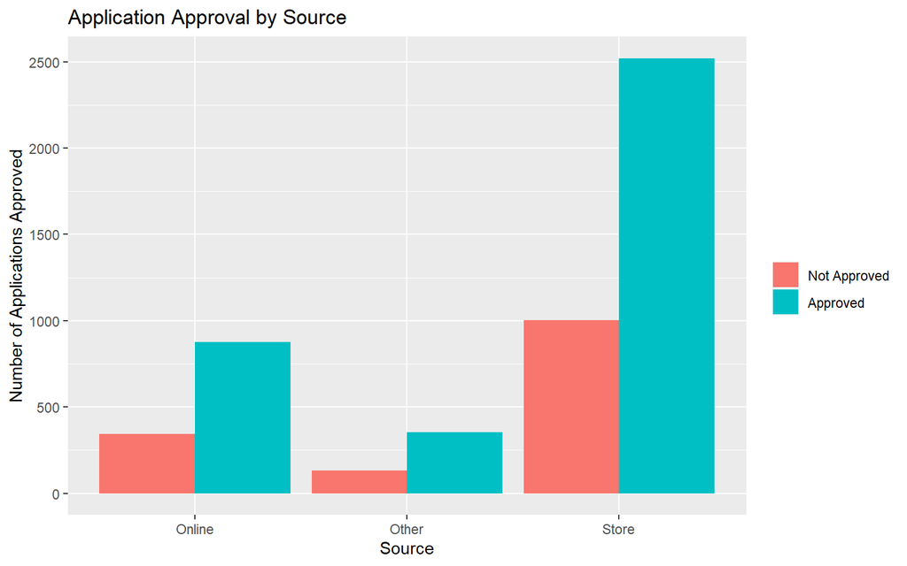

```r
ggplot(customer) +
    geom_bar(aes(x = application_source, fill = factor(approved)), position = position_dodge(preserve = 'single'))+
  scale_fill_discrete(name = "", labels = c("Not Approved", "Approved"))+
  xlab("Source")+
  ylab("Number of Applications Approved")+
  labs(title = "Application Approval by Source")
```

## 1.5 Which state has the highest total funded amount?

```r
colnames(merchant)[1] <- "merchant_id"

customer_state <- inner_join(customer, merchant,
                                  by ="merchant_id")


tibble <- customer_state %>%
  group_by(state) %>%
  summarise(across(funded_amount, sum, na.rm = TRUE))
tibble
```

```
## # A tibble: 3 x 2
##   state funded_amount
##   <chr>         <int>
## 1 FL          1111361
## 2 TX           388337
## 3 UT          1365658
```

Utah has the highest total funded amount.

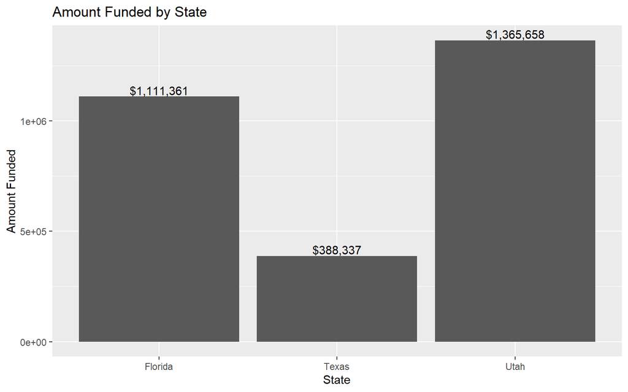

```r
statefund <- tibble(trt = c("Florida", "Texas", "Utah"), outcome = c(1111361, 388337, 1365658))
ggplot(statefund, aes(trt, outcome)) +
  geom_col()+
  geom_text(aes(label = c("$1,111,361", "$388,337", "$1,365,658")), vjust = -0.2)+
  xlab("State")+
  ylab("Amount Funded")+
  labs(title = "Amount Funded by State")
```

## 1.6 For the state in #5, how many total applications did they have each month?

```r
Utah <- filter(customer_state, state == "UT")

UtahMonth <- Utah

UtahMonth$submit_time <- as.Date(UtahMonth$submit_time,
  format = "%m/%d/%y")
UtahMonth$year <- strftime(UtahMonth$submit_time, "%Y")

UtahMonth$month <- strftime(UtahMonth$submit_time, "%m")

UtahMonth$approved[UtahMonth$approved == "0"] <- 1

UtahMonth_agg <- aggregate(approved ~ month + year,       # Aggregate data
                        UtahMonth,
                        FUN = sum)
colnames(UtahMonth_agg)[3] <- "Applications"
UtahMonth_agg <- select(UtahMonth_agg, month, Applications)
UtahMonth_agg
```

```
##    month Applications
## 1     01           54
## 2     02           70
## 3     03          100
## 4     04          129
## 5     05          146
## 6     06          181
## 7     07          232
## 8     08          228
## 9     09          249
## 10    10          300
## 11    11          338
## 12    12          352
```

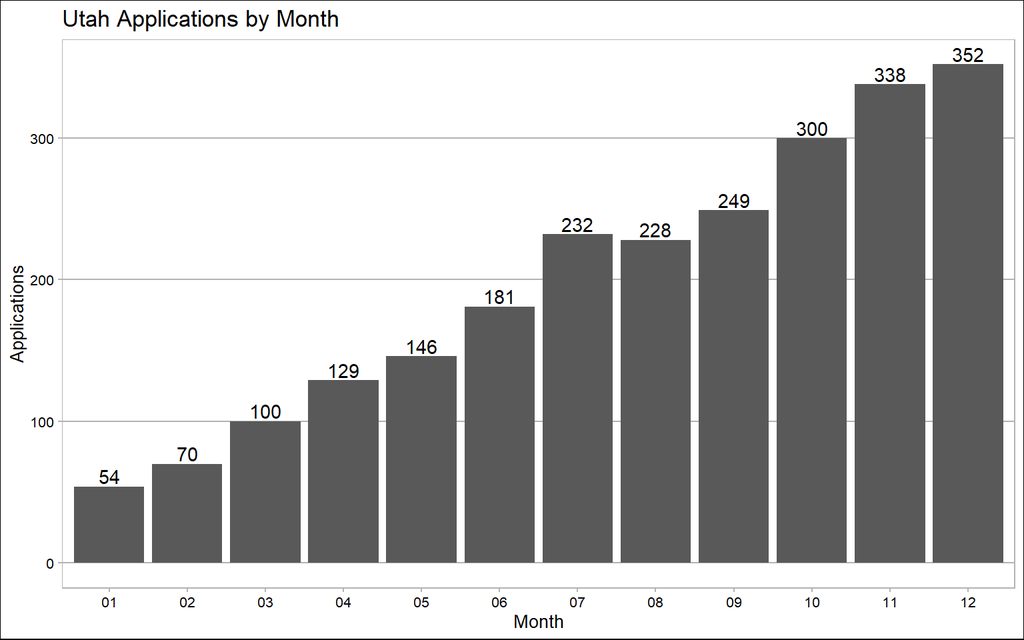

```r
ggplot(UtahMonth_agg) +
  aes(x = month, y = Applications) +
  geom_bar(stat='identity')+
  theme_calc()+ scale_colour_calc()+
  labs(title = "Utah Applications by Month") +
  xlab("Month")+
  geom_text(aes(label = c("54", "70", "100", "129", "146", "181", "232", "228", "249", "300", "338", "352"), vjust = -0.2))
```

This graph shows that in 2019, there was tremendous growth over the year. Starting in January with just 54 applications in the month, the year ended in December with 352 applications; almost seven times that of January.

## 1.7 EXTENSION: Is this real or superficial growth?

This trend of application growth made me wonder if the approval and completion rates varied with the increase in applications.

```r
Extension <- Utah

Extension$submit_time <- as.Date(Extension$submit_time,
  format = "%m/%d/%y")
Extension$year <- strftime(Extension$submit_time, "%Y")

Extension$month <- strftime(Extension$submit_time, "%m")

Extension%>%
  filter(month == "01")%>%
    count(approved = factor(approved))%>%
    mutate(pct = prop.table(n))
```

```
##   approved  n       pct
## 1        0 21 0.3888889
## 2        1 33 0.6111111
```

```r
Extension%>%
  filter(month == "02")%>%
    count(approved = factor(approved)) %>%
    mutate(pct = prop.table(n))
```

```
##   approved  n       pct
## 1        0 36 0.5142857
## 2        1 34 0.4857143
```

```r
Extension%>%
  filter(month == "03")%>%
    count(approved = factor(approved)) %>%
    mutate(pct = prop.table(n))
```

```
##   approved  n  pct
## 1        0 47 0.47
## 2        1 53 0.53
```

```r
Extension%>%
  filter(month == "04")%>%
    count(approved = factor(approved)) %>%
    mutate(pct = prop.table(n))
```

```
##   approved  n       pct
## 1        0 45 0.3488372
## 2        1 84 0.6511628
```

```r
Extension%>%
  filter(month == "05")%>%
    count(approved = factor(approved))%>%
    mutate(pct = prop.table(n))
```

```
##   approved   n       pct
## 1        0  43 0.2945205
## 2        1 103 0.7054795
```

```r
Extension%>%
  filter(month == "06")%>%
    count(approved = factor(approved)) %>%
    mutate(pct = prop.table(n))
```

```
##   approved   n       pct
## 1        0  53 0.2928177
## 2        1 128 0.7071823
```

```r
Extension%>%
  filter(month == "07")%>%
    count(approved = factor(approved)) %>%
    mutate(pct = prop.table(n))
```

```
##   approved   n       pct
## 1        0  66 0.2844828
## 2        1 166 0.7155172
```

```r
Extension%>%
  filter(month == "08")%>%
    count(approved = factor(approved)) %>%
    mutate(pct = prop.table(n))
```

```
##   approved   n      pct
## 1        0  58 0.254386
## 2        1 170 0.745614
```

```r
Extension%>%
  filter(month == "09")%>%
    count(approved = factor(approved))%>%
    mutate(pct = prop.table(n))
```

```
##   approved   n       pct
## 1        0  72 0.2891566
## 2        1 177 0.7108434
```

```r
Extension%>%
  filter(month == "10")%>%
    count(approved = factor(approved)) %>%
    mutate(pct = prop.table(n))
```

```
##   approved   n       pct
## 1        0  94 0.3133333
## 2        1 206 0.6866667
```

```r
Extension%>%
  filter(month == "11")%>%
    count(approved = factor(approved)) %>%
    mutate(pct = prop.table(n))
```

```
##   approved   n       pct
## 1        0  70 0.2071006
## 2        1 268 0.7928994
```

```r
Extension%>%
  filter(month == "12")%>%
    count(approved = factor(approved)) %>%
    mutate(pct = prop.table(n))
```

```
##   approved   n       pct
## 1        0  65 0.1846591
## 2        1 287 0.8153409
```

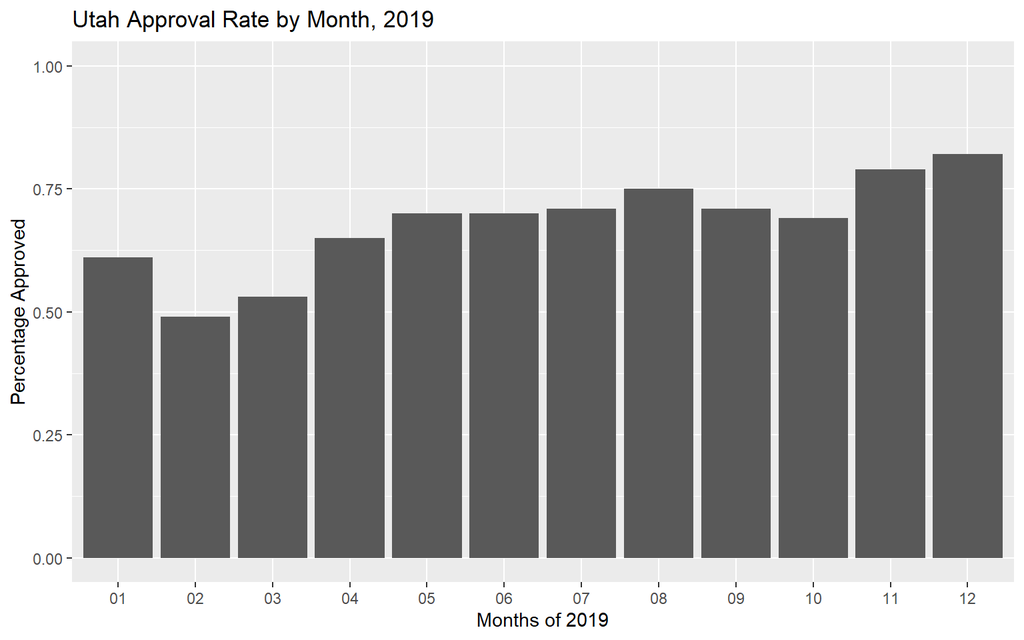

```r
monthapprov <- tibble(trt = c("01", "02", "03", "04", "05", "06", "07", "08", "09", "10", "11", "12"), outcome = c(0.61, 0.49, 0.53, 0.65, 0.70, 0.70, 0.71, 0.75, 0.71, 0.69, 0.79, 0.82))
ggplot(monthapprov, aes(trt, outcome)) +
  geom_col()+
  ylim(0,1)+

  xlab("Months of 2019")+
  ylab("Percentage Approved")+
  labs(title = "Utah Approval Rate by Month, 2019")
```

We see that there is a positive trend in the Approval rates to match the growth in Applications. What about completion rates? Are people actually getting the loans? Are we really doing more business?

```r
Extensioncomp <- subset(Extension, approved == 1)

Extensioncomp%>%
  filter(month == "01")%>%
    count(completed = factor(completed)) %>%
    mutate(pct = prop.table(n))
```

```
##   completed  n       pct
## 1         0 11 0.3333333
## 2         1 22 0.6666667
```

```r
Extensioncomp%>%
  filter(month == "02")%>%
    count(completed = factor(completed)) %>%
    mutate(pct = prop.table(n))
```

```
##   completed  n       pct
## 1         0 13 0.3823529
## 2         1 21 0.6176471
```

```r
Extensioncomp%>%
  filter(month == "03")%>%
    count(completed = factor(completed)) %>%
    mutate(pct = prop.table(n))
```

```
##   completed  n       pct
## 1         0 22 0.4150943
## 2         1 31 0.5849057
```

```r
Extensioncomp%>%
  filter(month == "04")%>%
    count(completed = factor(completed)) %>%
    mutate(pct = prop.table(n))
```

```
##   completed  n       pct
## 1         0 26 0.3095238
## 2         1 58 0.6904762
```

```r
Extensioncomp%>%
  filter(month == "05")%>%
    count(completed = factor(completed)) %>%
    mutate(pct = prop.table(n))
```

```
##   completed  n       pct
## 1         0 28 0.2718447
## 2         1 75 0.7281553
```

```r
Extensioncomp%>%
  filter(month == "06")%>%
    count(completed = factor(completed)) %>%
    mutate(pct = prop.table(n))
```

```
##   completed  n       pct
## 1         0 53 0.4140625
## 2         1 75 0.5859375
```

```r
Extensioncomp%>%
  filter(month == "07")%>%
    count(completed = factor(completed)) %>%
    mutate(pct = prop.table(n))
```

```
##   completed   n       pct
## 1         0  59 0.3554217
## 2         1 107 0.6445783
```

```r
Extensioncomp%>%
  filter(month == "08")%>%
    count(completed = factor(completed)) %>%
    mutate(pct = prop.table(n))
```

```
##   completed   n       pct
## 1         0  63 0.3705882
## 2         1 107 0.6294118
```

```r
Extensioncomp%>%
  filter(month == "09")%>%
    count(completed = factor(completed)) %>%
    mutate(pct = prop.table(n))
```

```
##   completed   n       pct
## 1         0  58 0.3276836
## 2         1 119 0.6723164
```

```r
Extensioncomp%>%
  filter(month == "10")%>%
    count(completed = factor(completed)) %>%
    mutate(pct = prop.table(n))
```

```
##   completed   n       pct
## 1         0  73 0.3543689
## 2         1 133 0.6456311
```

```r
Extensioncomp%>%
  filter(month == "11")%>%
    count(completed = factor(completed)) %>%
    mutate(pct = prop.table(n))
```

```
##   completed   n       pct
## 1         0 103 0.3843284
## 2         1 165 0.6156716
```

```r
Extensioncomp%>%
  filter(month == "12")%>%
    count(completed = factor(completed)) %>%
    mutate(pct = prop.table(n))
```

```
##   completed   n       pct
## 1         0 118 0.4111498
## 2         1 169 0.5888502
```

[figure not shown]

```r
monthcomp <- tibble(trt = c("01", "02", "03", "04", "05", "06", "07", "08", "09", "10", "11", "12"), outcome = c(0.66, 0.61, 0.58, 0.69, 0.73, 0.59, 0.64, 0.65, 0.67, 0.65, 0.62, 0.59))
ggplot(monthapprov, aes(trt, outcome)) +
  geom_col()+
  ylim(0,1)+

  xlab("Months of 2019")+
  ylab("Percentage Complete")+
  labs(title = "Utah Completion Rate by Month, 2019")
```

## 1.8 What questions do you have?

## 1.9 Thank you!